# results_summary

2024-06-13

## *Inclusion/Exclusion criteria*

- No diabetes data (Eastwood algorithm + HbA1c <5.7%)
- Complete data for glucose, genetic ancestry, and behavioral/SES covariates

Planned sensitivity analyses * Restrict to individuals with plausible total energy intakes : <20MJ for men; <18 MJ for women (range based on values considered plausible by UKB in DataShowcase with additional exclusions to those with >600 kcal, as a lower limit)

| European, *n* (%) | 362458 (100%) |
| --- | --- |
| Genotyping, *n* (%) | 362075 (99.9%) |
| T2D Controls, *n* (%) | 279805 (77.2%) |
| Complete covariate data, *n* (%) | 258307 (71.3%) |
| Fasting ≤24 hr, *n* (%) | 362419 (100%) |
| Analytial sample, *N* (%) | 241378 (66.6%) |

## Distribution of TAS2R38 Haplotypes & Diplotypes

We examined the distributions of common (frequency >0.0005) TAS2R38 genotypess

```
## Defaulting to continuous.
## Defaulting to continuous.
```

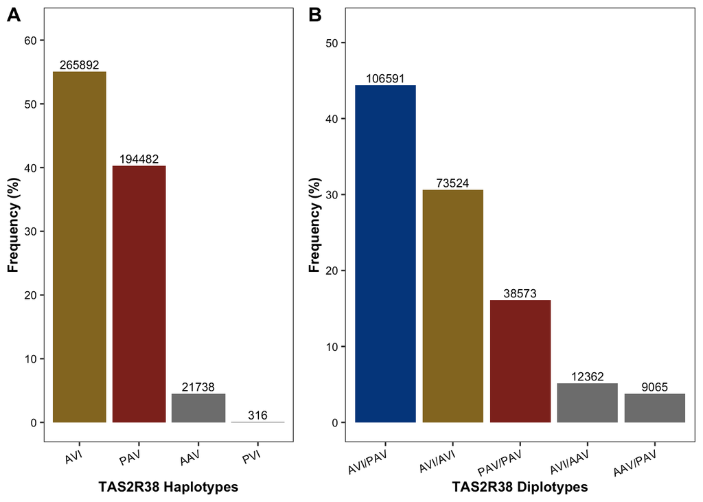

## Descriptive characteristics

We summarized demographic, behavioral and health characteristics among all identified TAS2R38 diplotypes.

Table 1 across TAS2R38 diplotypes (canonical)

|  | Total | AVI/AVI | AVI/PAV | PAV/PAV | P_value | P_trend |
| --- | --- | --- | --- | --- | --- | --- |
| N (%) | 218688 | 73524 (33.6%) | 106591 (48.7%) | 38573 (17.6%) | - | - |
| Age, years | 56.041 ± 8.084 | 56.032 ± 8.102 | 56.042 ± 8.082 | 56.058 ± 8.055 | 0.876828 | 0.618708 |
| Sex |  |  |  |  | 0.856914 | - |
| Male | 99968 (45.7%) | 33602 (45.7%) | 48685 (45.7%) | 17681 (45.8%) |  |  |
| Female | 118720 (54.3%) | 39922 (54.3%) | 57906 (54.3%) | 20892 (54.2%) |  |  |
| BMI, kg/m2 | 26.859 ± 4.383 | 26.854 ± 4.374 | 26.865 ± 4.38 | 26.851 ± 4.41 | 0.793922 | 0.981375 |
| Smoking |  |  |  |  | 0.624727 | - |
| Never | 122908 (56.2%) | 41432 (56.4%) | 59763 (56.1%) | 21713 (56.3%) |  |  |
| Previous | 75278 (34.4%) | 25238 (34.3%) | 36748 (34.5%) | 13292 (34.5%) |  |  |
| Current | 20502 (9.4%) | 6854 (9.3%) | 10080 (9.5%) | 3568 (9.2%) |  |  |
| Physical Activity, MET/wk |  |  |  |  | 0.656804 | - |
| Low | 49618 (22.7%) | 16587 (22.6%) | 24328 (22.8%) | 8703 (22.6%) |  |  |
| Moderate | 123809 (56.6%) | 41654 (56.7%) | 60255 (56.5%) | 21900 (56.8%) |  |  |
| High | 45261 (20.7%) | 15283 (20.8%) | 22008 (20.6%) | 7970 (20.7%) |  |  |
| Alcohol Frequency |  |  |  |  | 0.007304 | - |
| Daily or almost daily | 49031 (22.4%) | 16662 (22.7%) | 23930 (22.5%) | 8439 (21.9%) |  |  |
| 3-4 per week | 55123 (25.2%) | 18536 (25.2%) | 26964 (25.3%) | 9623 (24.9%) |  |  |
| 1-2 per week | 57516 (26.3%) | 19474 (26.5%) | 27777 (26.1%) | 10265 (26.6%) |  |  |
| 1-3 per month | 23442 (10.7%) | 7793 (10.6%) | 11484 (10.8%) | 4165 (10.8%) |  |  |
| Special occasions only | 20825 (9.5%) | 6875 (9.4%) | 10172 (9.5%) | 3778 (9.8%) |  |  |
| Never1 | 12751 (5.8%) | 4184 (5.7%) | 6264 (5.9%) | 2303 (6%) |  |  |
| Alcohol intake (among drinkers) | 23.21 ± 20.656 | 23.198 ± 20.618 | 23.276 ± 20.711 | 23.046 ± 20.578 | 0.600439 | 0.934264 |
| Education Level |  |  |  |  | 0.328023 | - |
| College or university degree | 74177 (34.2%) | 24994 (34%) | 36103 (33.9%) | 13080 (33.9%) |  |  |
| NVQ/HND or equivalent | 13824 (6.4%) | 4617 (6.3%) | 6769 (6.4%) | 2438 (6.3%) |  |  |
| Other professional qualifications | 10909 (5%) | 3736 (5.1%) | 5199 (4.9%) | 1974 (5.1%) |  |  |
| A/AS levels or equivalent | 25841 (11.9%) | 8699 (11.8%) | 12724 (11.9%) | 4418 (11.5%) |  |  |
| O/GCSE levels or equivalent | 47802 (22%) | 16093 (21.9%) | 23280 (21.8%) | 8429 (21.9%) |  |  |
| CSEs or equivalent | 12036 (5.5%) | 4053 (5.5%) | 5851 (5.5%) | 2132 (5.5%) |  |  |
| None of the above | 32451 (15%) | 10799 (14.7%) | 15858 (14.9%) | 5794 (15%) |  |  |
| Income Level |  |  |  |  | 0.025775 | - |
| lt_18000 | 37006 (19.5%) | 12570 (17.1%) | 17853 (16.7%) | 6583 (17.1%) |  |  |
| from_18000_to_30999 | 46961 (24.7%) | 15892 (21.6%) | 22834 (21.4%) | 8235 (21.3%) |  |  |
| from_31000_to_51999 | 51924 (27.3%) | 17562 (23.9%) | 25317 (23.8%) | 9045 (23.4%) |  |  |
| from_52000_to_100000 | 42877 (22.5%) | 14128 (19.2%) | 21173 (19.9%) | 7576 (19.6%) |  |  |
| gt_100000 | 11445 (6%) | 3848 (5.2%) | 5533 (5.2%) | 2064 (5.4%) |  |  |
| Glucose, mmol/L | 4.913 ± 0.585 | 4.916 ± 0.585 | 4.913 ± 0.586 | 4.907 ± 0.58 | 0.056392 | 0.015619 |
| HbA1C, % | 5.26 ± 0.268 | 5.258 ± 0.268 | 5.261 ± 0.268 | 5.26 ± 0.267 | 0.220282 | 0.344361 |
| SBP, mmHg | 139.144 ± 19.578 | 139.057 ± 19.553 | 139.183 ± 19.582 | 139.201 ± 19.615 | 0.305022 | 0.234238 |
| DBP, mmHg | 82.102 ± 10.654 | 82.077 ± 10.667 | 82.1 ± 10.658 | 82.154 ± 10.615 | 0.531795 | 0.304062 |
| Triglyceride, mmol/L | 1.677 ± 0.973 | 1.678 ± 0.968 | 1.677 ± 0.975 | 1.675 ± 0.973 | 0.908058 | 0.615278 |
| LDL, mmol/L | 3.609 ± 0.836 | 3.607 ± 0.835 | 3.609 ± 0.837 | 3.611 ± 0.832 | 0.752786 | 0.468656 |
| HDL, mmol/L | 1.482 ± 0.382 | 1.482 ± 0.382 | 1.482 ± 0.382 | 1.48 ± 0.381 | 0.53079 | 0.414884 |
| Coffee, cups/day | 2.056 ± 1.982 | 2.071 ± 1.979 | 2.057 ± 1.99 | 2.022 ± 1.965 | 0.000474 | 0.000191 |
| Tea, cups/day | 3.424 ± 2.712 | 3.401 ± 2.717 | 3.427 ± 2.707 | 3.456 ± 2.719 | 0.004509 | 0.001134 |
| Added salt |  |  |  |  | 0 | - |
| Always/Often | 33680 (15.4%) | 11809 (16.1%) | 16354 (15.3%) | 5517 (14.3%) |  |  |
| Sometimes | 60272 (27.6%) | 20681 (28.1%) | 29240 (27.4%) | 10351 (26.8%) |  |  |
| Never/Rarely | 124725 (57%) | 41029 (55.8%) | 60994 (57.2%) | 22702 (58.9%) |  |  |

## TAS2R38 and food choices

##### Check whether diplotypes captured expected phenotypic differences in bitter-related diet trait

|  | Total | AVI/AVI | AVI/PAV | PAV/PAV | P_value | P_trend |
| --- | --- | --- | --- | --- | --- | --- |
| N (%) | 218688 | 73524 (33.6%) | 106591 (48.7%) | 38573 (17.6%) | - | - |
| Coffee, cups/day | 2.06 ± 1.98 | 2.07 ± 1.98 | 2.06 ± 1.99 | 2.02 ± 1.96 | 0.000474 | 0.000191 |
| Tea, cups/day | 3.42 ± 2.71 | 3.4 ± 2.72 | 3.43 ± 2.71 | 3.46 ± 2.72 | 0.004509 | 0.001134 |
| Raw vegetables, tbsp/day | 2.15 ± 2.03 | 2.16 ± 2.02 | 2.15 ± 2.03 | 2.13 ± 2.04 | 0.11591 | 0.042616 |
| Alcohol, g/day | 15.77 ± 20.17 | 15.82 ± 20.16 | 15.84 ± 20.23 | 15.47 ± 20.03 | 0.108823 | 0.160616 |
| Heavy drinker | 104154 (47.6%) | 35198 (47.9%) | 50894 (47.7%) | 18062 (46.8%) | 0.002101 | - |

##### Compare food choice patterns across TAS2R38 diplotypes

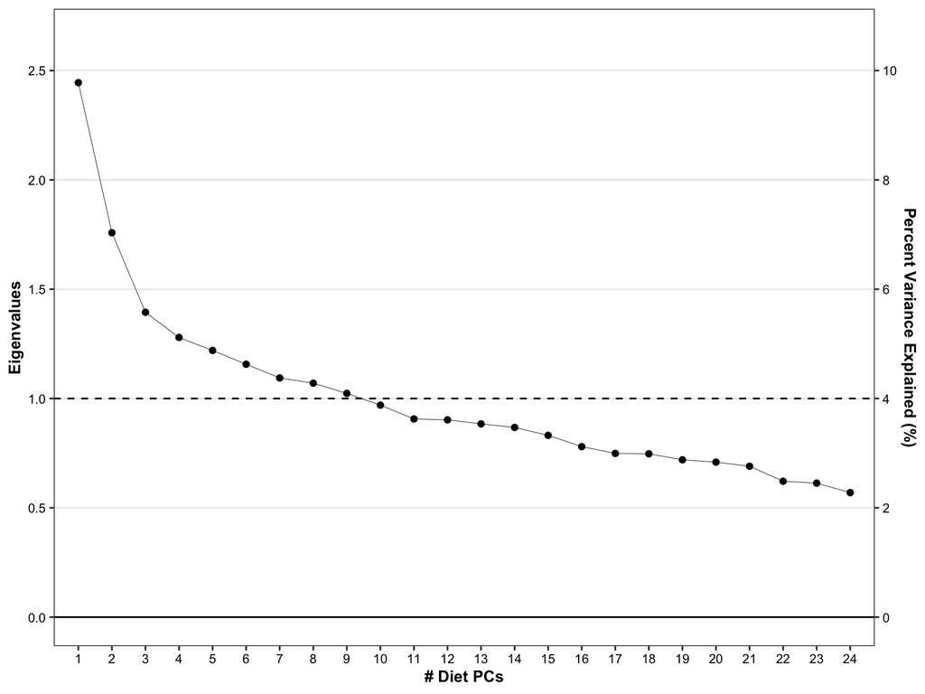

#### Examine adherence to the food choice patterns by canonical TAS2R38 diplotypes

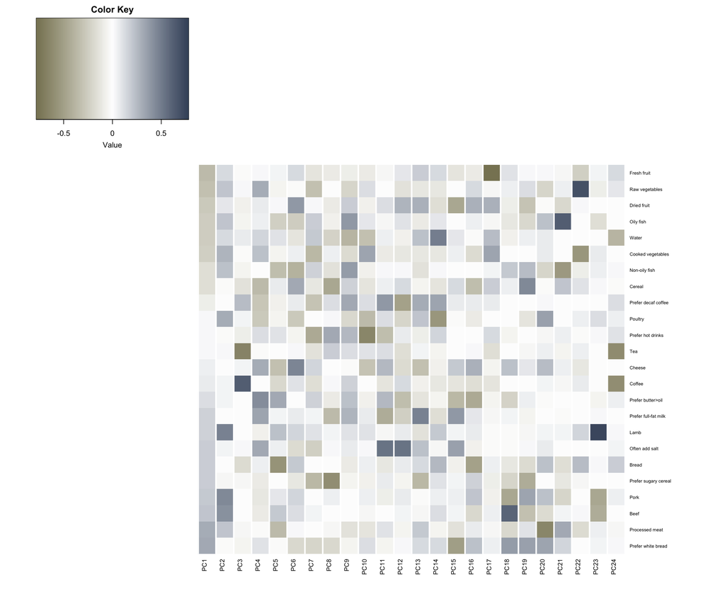

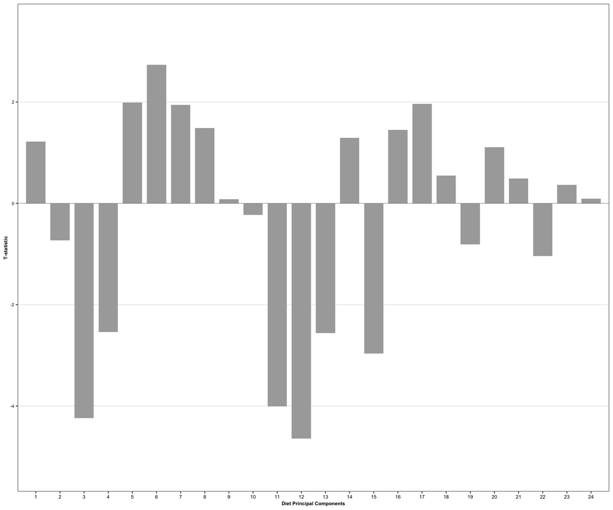

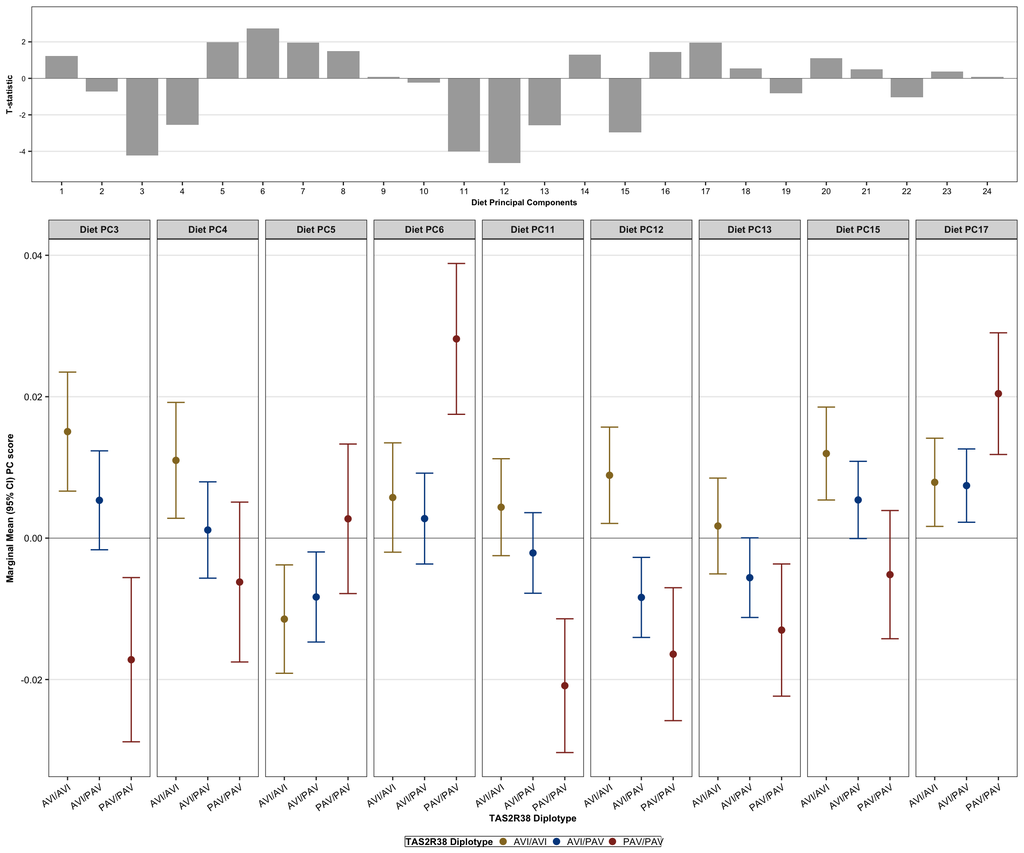

## Primary Analysis

#### Asssociations of canonical TAS2R38 diplotype with markers of glucose homeostasis random glucose & a1c

Descriptive comparisons: Mean (SD) with sex- and age-adjusted P-values

Mean (SD) glycemic measures by Diplotype

|  | Fasting | Total | AVI/AVI | AVI/PAV | PAV/PAV | P_value | P_trend |
| --- | --- | --- | --- | --- | --- | --- | --- |
| N (%) | Random | 218688 | 73524 (34%) | 106591 (49%) | 38573 (18%) | - | - |
| Glucose | Random | 4.913 ± 0.585 | 4.916 ± 0.585 | 4.913 ± 0.586 | 4.907 ± 0.58 | 0.056392 | 0.015619 |
| 0-2hr Glucose | Random | 4.953 ± 0.743 | 4.965 ± 0.743 | 4.949 ± 0.748 | 4.942 ± 0.731 | 0.018134 | 0.004378 |
| HbA1c | Random | 5.26 ± 0.268 | 5.258 ± 0.268 | 5.261 ± 0.268 | 5.26 ± 0.267 | 0.220282 | 0.344361 |

Summarize descriptive comparisons (for glucose)

Descriptive comparisons of random glucose by TAS2R38 diplotyoe (categorical)

|  | n | beta | se | p | f | f_p |
| --- | --- | --- | --- | --- | --- | --- |
| Sex/age-adj RG_AVI/AVI | 73524 | NA | NA | NA | 2.875470 | 0.0563917 |
| Sex/age-adj RG_AVI/PAV | 106591 | -0.0032441 | 0.0027769 | 0.2427035 | NA | NA |
| Sex/age-adj RG_PAV/PAV | 38573 | -0.0089808 | 0.0036416 | 0.0136590 | NA | NA |
| Sex/age/gPC-adj RG_AVI/AVI | 73524 | NA | NA | NA | 2.876627 | 0.0563266 |
| Sex/age/gPC-adj RG_AVI/PAV | 106591 | -0.0031370 | 0.0027766 | 0.2585580 | NA | NA |
| Sex/age/gPC-adj RG_PAV/PAV | 38573 | -0.0088887 | 0.0036414 | 0.0146469 | NA | NA |

Descriptive comparisons of random glucose by TAS2R38 diplotyoe (continuous per PAV haplotype)

|  | Model | beta | se | p |
| --- | --- | --- | --- | --- |
| taste_diplos.num | Sex/age-adj RG | -0.00429105441232034 | 0.0017748389718268 | 0.0156191257387476 |
| taste_diplos.num1 | Sex/age/gPC-adj RG | -0.00423525931550041 | 0.00177473247024804 | 0.0170140948871585 |

Descriptive comparisons of 0-2hr glucose by TAS2R38 diplotyoe (categorical)

|  | n | beta | se | p | f | f_p |
| --- | --- | --- | --- | --- | --- | --- |
| Sex/age-adj RG_AVI/AVI | 19489 | NA | NA | NA | 4.01022 | 0.0181345 |
| Sex/age-adj RG_AVI/PAV | 28110 | -0.0148767 | 0.0068519 | 0.0299210 | NA | NA |
| Sex/age-adj RG_PAV/PAV | 10053 | -0.0241103 | 0.0090264 | 0.0075629 | NA | NA |
| Sex/age/gPC-adj RG_AVI/AVI | 19489 | NA | NA | NA | 4.01344 | 0.0180762 |
| Sex/age/gPC-adj RG_AVI/PAV | 28110 | -0.0143777 | 0.0068506 | 0.0358447 | NA | NA |
| Sex/age/gPC-adj RG_PAV/PAV | 10053 | -0.0246060 | 0.0090249 | 0.0064037 | NA | NA |

Descriptive comparisons of 0-2hr glucose by TAS2R38 diplotyoe (continuous per PAV haplotype)

|  | Model | beta | se | p |
| --- | --- | --- | --- | --- |
| taste_diplos.num | Sex/age-adj RG | -0.0125188488639187 | 0.00439313296945183 | 0.00437842034775754 |
| taste_diplos.num1 | Sex/age/gPC-adj RG | -0.0126439670913811 | 0.00439233111247679 | 0.00399533002922593 |

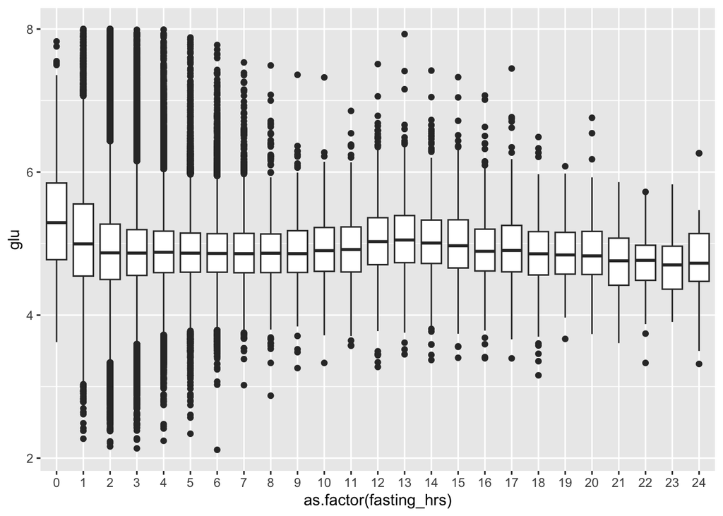

### Associations of TAS2R38 diplotype with glycemic measures

We used generalized linear models with 4 models. * Exposure: categorical diplotype (reference = AVI/AVI) * Outcomes: continunous glycemic measures * Covariates: 4 models; base, bmi, lifestyle, food choices

Associations of TAS2R38 diplotype with Random Glucose

| Model | Exposure | N | Beta_95CI | P | F.test_P | T.test_P |
| --- | --- | --- | --- | --- | --- | --- |
| Base | AVI/AVI | 73524 | - | - | 0.05576 | 0.019962 |
| Base | AVI/PAV | 106591 | -0.003 (-0.009, 0.002) | 0.255965392389088 | - | - |
| Base | PAV/PAV | 38573 | -0.009 (-0.016, -0.001) | 0.0177718294423106 | - | - |
| BMI | AVI/AVI | 73524 | - | - | 0.054689 | 0.020878 |
| BMI | AVI/PAV | 106591 | -0.003 (-0.009, 0.002) | 0.244848129435498 | - | - |
| BMI | PAV/PAV | 38573 | -0.008 (-0.016, -0.001) | 0.0191324724308044 | - | - |
| Lifestyle | AVI/AVI | 73524 | - | - | 0.054088 | 0.034391 |
| Lifestyle | AVI/PAV | 106591 | -0.003 (-0.008, 0.003) | 0.294711760998869 | - | - |
| Lifestyle | PAV/PAV | 38573 | -0.008 (-0.015, -0.001) | 0.0315230019742015 | - | - |
| Diet.Patterns | AVI/AVI | 73524 | - | - | 0.053852 | 0.033863 |
| Diet.Patterns | AVI/PAV | 106591 | -0.003 (-0.008, 0.002) | 0.288970211102456 | - | - |
| Diet.Patterns | PAV/PAV | 38573 | -0.008 (-0.015, -0.001) | 0.0312349038673288 | - | - |

Associations of TAS2R38 diplotype with 0-2hr Glucose

| Model | Exposure | N | Beta_95CI | P | F.test_P | T.test_P |
| --- | --- | --- | --- | --- | --- | --- |
| Base | AVI/AVI | 19489 | - | - | 0.018076 | 0.003995 |
| Base | AVI/PAV | 28110 | -0.014 (-0.028, -0.001) | 0.0358447144570994 | - | - |
| Base | PAV/PAV | 10053 | -0.025 (-0.042, -0.007) | 0.00640367616042155 | - | - |
| BMI | AVI/AVI | 19489 | - | - | 0.01708 | 0.005156 |
| BMI | AVI/PAV | 28110 | -0.014 (-0.027, -0.001) | 0.0400129181871616 | - | - |
| BMI | PAV/PAV | 10053 | -0.024 (-0.041, -0.006) | 0.00816913020304405 | - | - |
| Lifestyle | AVI/AVI | 19489 | - | - | 0.016944 | 0.00676 |
| Lifestyle | AVI/PAV | 28110 | -0.013 (-0.027, 0) | 0.0483209211167069 | - | - |
| Lifestyle | PAV/PAV | 10053 | -0.023 (-0.041, -0.005) | 0.0103086857712681 | - | - |
| Diet.Patterns | AVI/AVI | 19489 | - | - | 0.016829 | 0.005239 |
| Diet.Patterns | AVI/PAV | 28110 | -0.014 (-0.027, 0) | 0.0445297505885889 | - | - |
| Diet.Patterns | PAV/PAV | 10053 | -0.024 (-0.041, -0.006) | 0.00799506422558713 | - | - |

Associations of TAS2R38 diplotype with HbA1c

| Model | Exposure | N | Beta_95CI | P | F.test_P | T.test_P |
| --- | --- | --- | --- | --- | --- | --- |
| Base | AVI/AVI | 73524 | - | - | 0.220218 | 0.32931 |
| Base | AVI/PAV | 106591 | 0.002 (0, 0.005) | 0.0935983071380544 | - | - |
| Base | PAV/PAV | 38573 | 0.001 (-0.002, 0.004) | 0.518847986113691 | - | - |
| BMI | AVI/AVI | 73524 | - | - | 0.217159 | 0.313005 |
| BMI | AVI/PAV | 106591 | 0.002 (0, 0.004) | 0.0974643108580995 | - | - |
| BMI | PAV/PAV | 38573 | 0.001 (-0.002, 0.004) | 0.490472623459851 | - | - |
| Lifestyle | AVI/AVI | 73524 | - | - | 0.213067 | 0.400381 |
| Lifestyle | AVI/PAV | 106591 | 0.002 (-0.001, 0.004) | 0.129864460767684 | - | - |
| Lifestyle | PAV/PAV | 38573 | 0.001 (-0.002, 0.004) | 0.591938194504404 | - | - |
| Diet.Patterns | AVI/AVI | 73524 | - | - | 0.21275 | 0.490947 |
| Diet.Patterns | AVI/PAV | 106591 | 0.002 (-0.001, 0.004) | 0.146947437461491 | - | - |
| Diet.Patterns | PAV/PAV | 38573 | 0.001 (-0.003, 0.004) | 0.705386950280371 | - | - |

#### Comparative analysis looked across all fasting windows

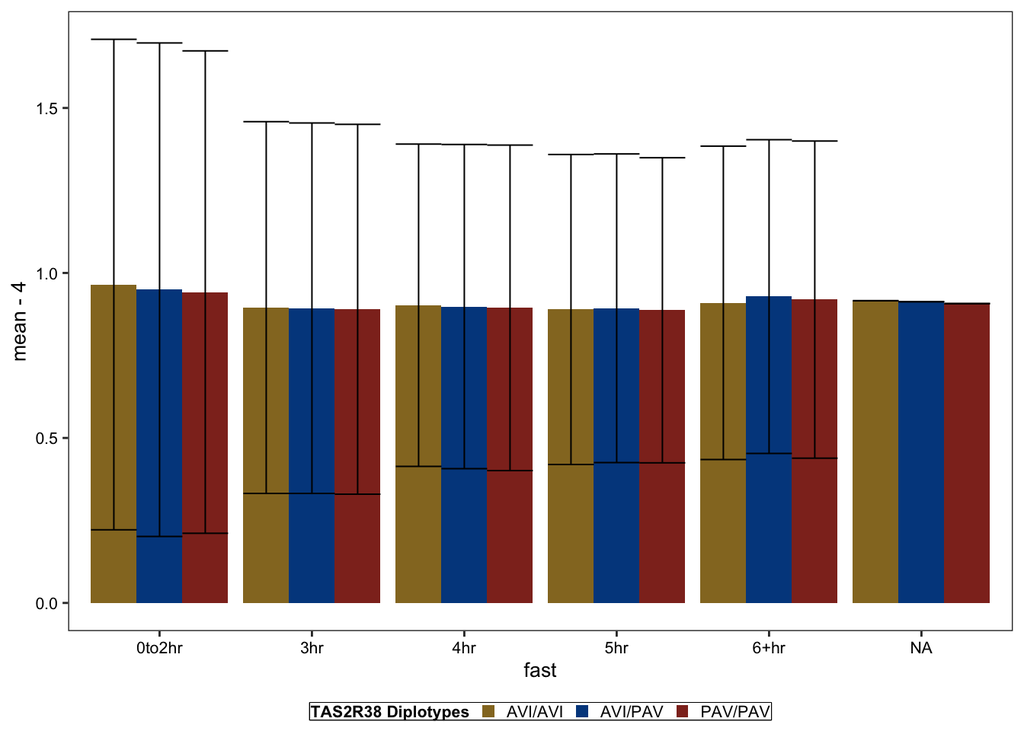

| fast_cat | Taste_AVI.AVI | Taste_AVI.PAV | Taste_PAV.PAV | Sex_Female | Sex_Male |
| --- | --- | --- | --- | --- | --- |
| 0to2hr | 19489 (30.6%) | 28110 (44.2%) | 10053 (15.8%) | 34499 (54.2%) | 29128 (45.8%) |
| 3hr | 21794 (30.5%) | 31370 (43.9%) | 11565 (16.2%) | 39818 (55.7%) | 31609 (44.3%) |
| 4hr | 15852 (30.3%) | 23091 (44.2%) | 8392 (16.1%) | 29019 (55.5%) | 23261 (44.5%) |
| 5hr | 8740 (30.7%) | 12597 (44.3%) | 4494 (15.8%) | 15377 (54%) | 13090 (46%) |
| 6+hr | 7649 (29.9%) | 11423 (44.7%) | 4069 (15.9%) | 12260 (47.9%) | 13317 (52.1%) |

##### Primary regression analysis

Associations of TAS2R38 with Glucose, Stratified by Fasting Window

| Model | Exposure | N | Beta_95CI | P | F.test_P | T.test_P |
| --- | --- | --- | --- | --- | --- | --- |
| Base | AVI/AVI | 19489 | - | - | 0.018076 | 0.003995 |
| Base | AVI/PAV | 28110 | -0.014 (-0.028, -0.001) | 0.0358447144570994 | - | - |
| Base | PAV/PAV | 10053 | -0.025 (-0.042, -0.007) | 0.00640367616042155 | - | - |
| BMI | AVI/AVI | 19489 | - | - | 0.01708 | 0.005156 |
| BMI | AVI/PAV | 28110 | -0.014 (-0.027, -0.001) | 0.0400129181871616 | - | - |
| BMI | PAV/PAV | 10053 | -0.024 (-0.041, -0.006) | 0.00816913020304405 | - | - |
| Lifestyle | AVI/AVI | 19489 | - | - | 0.016944 | 0.00676 |
| Lifestyle | AVI/PAV | 28110 | -0.013 (-0.027, 0) | 0.0483209211167069 | - | - |
| Lifestyle | PAV/PAV | 10053 | -0.023 (-0.041, -0.005) | 0.0103086857712681 | - | - |
| Diet.Patterns | AVI/AVI | 19489 | - | - | 0.016829 | 0.005239 |
| Diet.Patterns | AVI/PAV | 28110 | -0.014 (-0.027, 0) | 0.0445297505885889 | - | - |
| Diet.Patterns | PAV/PAV | 10053 | -0.024 (-0.041, -0.006) | 0.00799506422558713 | - | - |
| Base | AVI/AVI | 21794 | - | - | 0.716554 | 0.393988 |
| Base | AVI/PAV | 31370 | -0.002 (-0.012, 0.007) | 0.640289477360434 | - | - |
| Base | PAV/PAV | 11565 | -0.005 (-0.018, 0.007) | 0.393597919752941 | - | - |
| BMI | AVI/AVI | 21794 | - | - | 0.714153 | 0.401695 |
| BMI | AVI/PAV | 31370 | -0.002 (-0.012, 0.007) | 0.627648757853486 | - | - |
| BMI | PAV/PAV | 11565 | -0.005 (-0.018, 0.007) | 0.405348957613423 | - | - |
| Lifestyle | AVI/AVI | 21794 | - | - | 0.712824 | 0.506159 |
| Lifestyle | AVI/PAV | 31370 | -0.002 (-0.012, 0.008) | 0.679720305704874 | - | - |
| Lifestyle | PAV/PAV | 11565 | -0.004 (-0.017, 0.008) | 0.514622947328715 | - | - |
| Diet.Patterns | AVI/AVI | 21794 | - | - | 0.712162 | 0.486501 |
| Diet.Patterns | AVI/PAV | 31370 | -0.002 (-0.012, 0.007) | 0.653769742256256 | - | - |
| Diet.Patterns | PAV/PAV | 11565 | -0.004 (-0.017, 0.008) | 0.498117855944713 | - | - |
| Base | AVI/AVI | 15852 | - | - | 0.464644 | 0.314604 |
| Base | AVI/PAV | 23091 | -0.003 (-0.013, 0.007) | 0.512858892893157 | - | - |
| Base | PAV/PAV | 8392 | -0.006 (-0.019, 0.006) | 0.328414154416251 | - | - |
| BMI | AVI/AVI | 15852 | - | - | 0.464107 | 0.299275 |
| BMI | AVI/PAV | 23091 | -0.003 (-0.013, 0.007) | 0.523587407859506 | - | - |
| BMI | PAV/PAV | 8392 | -0.007 (-0.02, 0.006) | 0.307938626864608 | - | - |
| Lifestyle | AVI/AVI | 15852 | - | - | 0.462249 | 0.306219 |
| Lifestyle | AVI/PAV | 23091 | -0.003 (-0.013, 0.007) | 0.530271630400252 | - | - |
| Lifestyle | PAV/PAV | 8392 | -0.007 (-0.019, 0.006) | 0.314729645196416 | - | - |
| Diet.Patterns | AVI/AVI | 15852 | - | - | 0.461922 | 0.301058 |
| Diet.Patterns | AVI/PAV | 23091 | -0.003 (-0.013, 0.007) | 0.546146604479245 | - | - |
| Diet.Patterns | PAV/PAV | 8392 | -0.007 (-0.02, 0.006) | 0.30538403280712 | - | - |
| Base | AVI/AVI | 8740 | - | - | 0.700353 | 0.977772 |
| Base | AVI/PAV | 12597 | 0.004 (-0.009, 0.016) | 0.579548024961976 | - | - |
| Base | PAV/PAV | 4494 | -0.002 (-0.018, 0.015) | 0.842367142838381 | - | - |
| BMI | AVI/AVI | 8740 | - | - | 0.700299 | 0.976671 |
| BMI | AVI/PAV | 12597 | 0.003 (-0.009, 0.016) | 0.590357331887745 | - | - |
| BMI | PAV/PAV | 4494 | -0.002 (-0.018, 0.015) | 0.844803900468557 | - | - |
| Lifestyle | AVI/AVI | 8740 | - | - | 0.699281 | 0.942004 |
| Lifestyle | AVI/PAV | 12597 | 0.004 (-0.009, 0.016) | 0.579027975392117 | - | - |
| Lifestyle | PAV/PAV | 4494 | -0.001 (-0.017, 0.016) | 0.934752904950574 | - | - |
| Diet.Patterns | AVI/AVI | 8740 | - | - | 0.699234 | 0.930883 |
| Diet.Patterns | AVI/PAV | 12597 | 0.004 (-0.009, 0.016) | 0.556740040497288 | - | - |
| Diet.Patterns | PAV/PAV | 4494 | -0.001 (-0.017, 0.016) | 0.939888965907876 | - | - |
| Base | AVI/AVI | 7649 | - | - | 0.023714 | 0.123945 |
| Base | AVI/PAV | 11423 | 0.017 (0.004, 0.031) | 0.0132661596638085 | - | - |
| Base | PAV/PAV | 4069 | 0.01 (-0.008, 0.028) | 0.282789455347759 | - | - |
| BMI | AVI/AVI | 7649 | - | - | 0.023341 | 0.114102 |
| BMI | AVI/PAV | 11423 | 0.017 (0.003, 0.03) | 0.0153753937138791 | - | - |
| BMI | PAV/PAV | 4069 | 0.01 (-0.007, 0.028) | 0.255383585574281 | - | - |
| Lifestyle | AVI/AVI | 7649 | - | - | 0.022572 | 0.097582 |
| Lifestyle | AVI/PAV | 11423 | 0.017 (0.003, 0.03) | 0.0162984453539835 | - | - |
| Lifestyle | PAV/PAV | 4069 | 0.011 (-0.007, 0.029) | 0.217863733650891 | - | - |
| Diet.Patterns | AVI/AVI | 7649 | - | - | 0.022412 | 0.075182 |
| Diet.Patterns | AVI/PAV | 11423 | 0.017 (0.003, 0.03) | 0.0161277192413971 | - | - |
| Diet.Patterns | PAV/PAV | 4069 | 0.012 (-0.005, 0.03) | 0.169745461656834 | - | - |

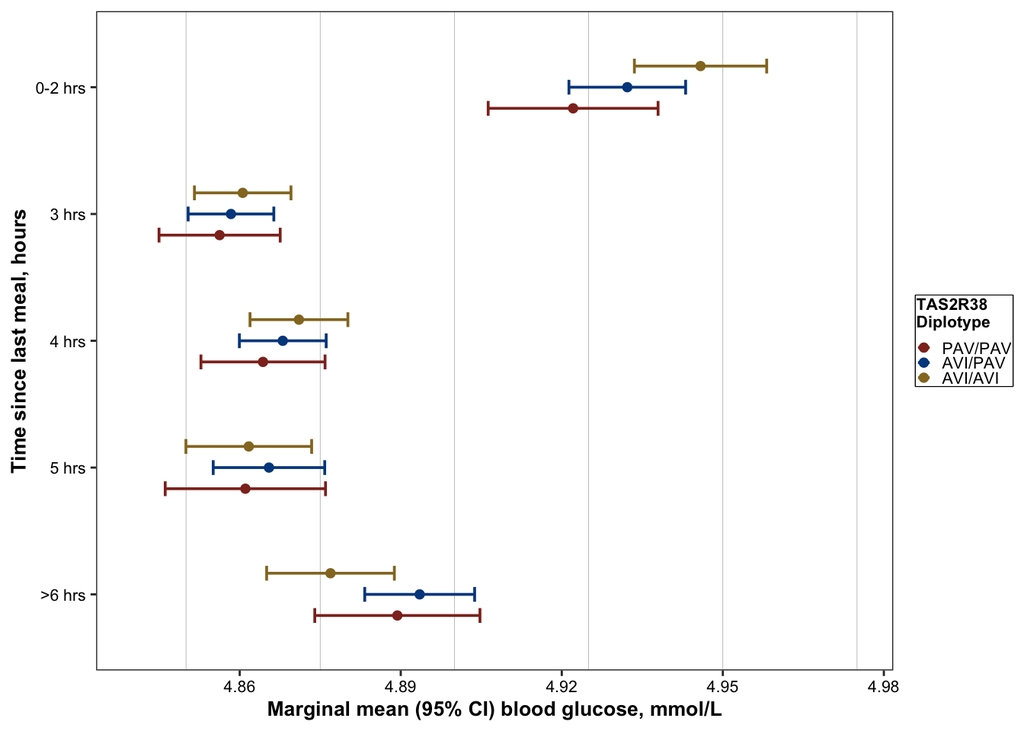

#### End of primary analysis tables & figures